# K-Nearest Neighbor

BIOS635 Introduction to Machine Learning

# R Markdown

R Markdown is a format for writing reproducible, dynamic reports with R. Use it to embed R code and results into slideshows, pdfs, html documents, Word files and more. Detailed instructions can be found [here](https://rstudio.com/wp-content/uploads/2015/02/rmarkdown-cheatsheet.pdf).

# K-nearest neighbor algorithm

In pattern recognition, the k-nearest neighbors algorithm (k-NN) is a non-parametric method used for classification and regression. In both cases, the input consists of the k closest training examples in the feature space. The output depends on whether k-NN is used for classification or regression:

- In k-NN classification, the output is a class membership. An object is classified by a plurality vote of its neighbors, with the object being assigned to the class most common among its k nearest neighbors (k is a positive integer, typically small). If k = 1, then the object is simply assigned to the class of that single nearest neighbor.
- In k-NN regression, the output is the property value for the object. This value is the average of the values of k nearest neighbors.

# Toy data set: Iris

Numerous guides have been written on the exploration of this widely known dataset. Iris, introduced by Ronald Fisher in his 1936 paper The use of multiple measurements in taxonomic problems, contains three plant species (setosa, virginica, versicolor) and four features measured for each sample. These quantify the morphologic variation of the iris flower in its three species, all measurements given in centimeters.

- `Sepal.Length` = measurements in centimeters of the variables sepal length.
- `Sepal.Width` = measurements in centimeters of the variables sepal width.
- `Petal.Length` = measurements in centimeters of the variables petal length.
- `Petal.Width` = measurements in centimeters of the variables petal width.
- `Species` = three species are Iris setosa, versicolor, and virginica.

```r
library(datasets)
data(iris)
summary(iris)
```

```
##   Sepal.Length    Sepal.Width     Petal.Length    Petal.Width
##  Min.   :4.300   Min.   :2.000   Min.   :1.000   Min.   :0.100
##  1st Qu.:5.100   1st Qu.:2.800   1st Qu.:1.600   1st Qu.:0.300
##  Median :5.800   Median :3.000   Median :4.350   Median :1.300
##  Mean   :5.843   Mean   :3.057   Mean   :3.758   Mean   :1.199
##  3rd Qu.:6.400   3rd Qu.:3.300   3rd Qu.:5.100   3rd Qu.:1.800
##  Max.   :7.900   Max.   :4.400   Max.   :6.900   Max.   :2.500
##        Species
##  setosa    :50
##  versicolor:50
##  virginica :50
##
##
##
```

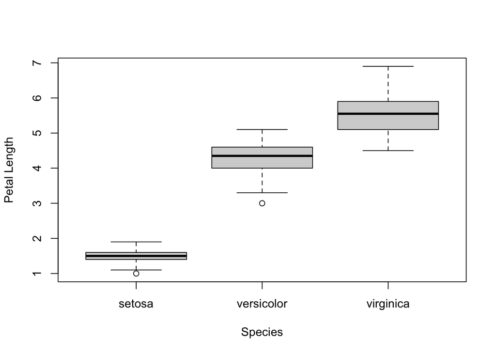

```r
boxplot(iris$Petal.Length~iris$Species, xlab='Species', ylab='Petal Length')
```

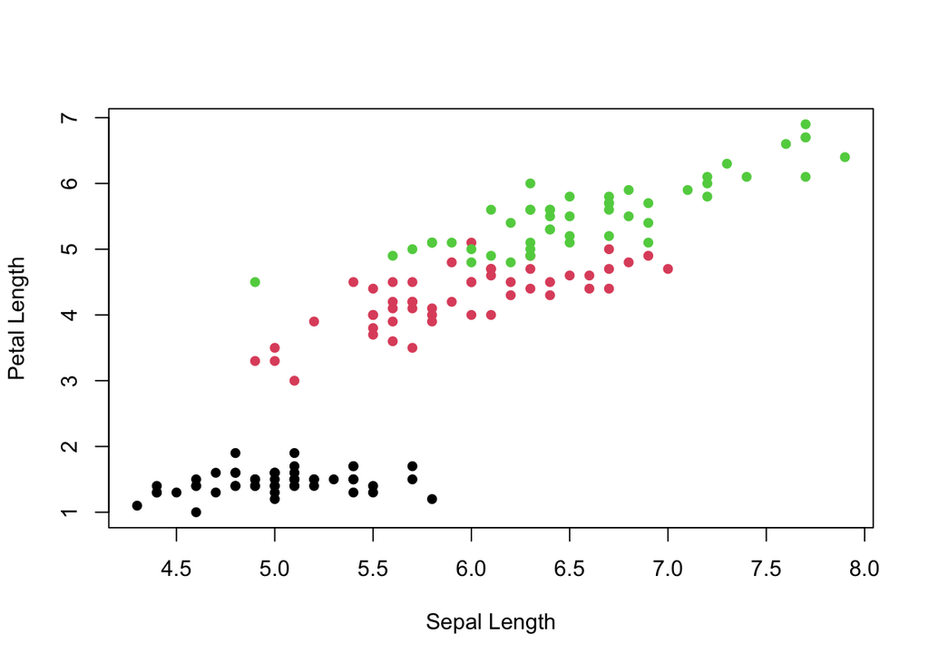

```r
plot(iris$Sepal.Length, iris$Petal.Length,
     xlab='Sepal Length', ylab='Petal Length',
     col=iris$Species, pch=16)
```

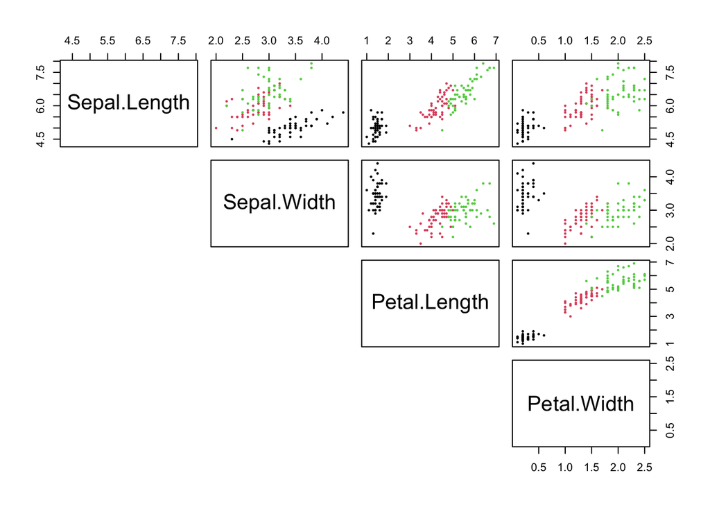

```r
pairs(iris[1:4], pch=16, cex=0.5, col=iris$Species, lower.panel = NULL)
```

We will first split the data into 30% test and 70% training.

```r
dim(iris)
```

```
## [1] 150   5
```

```r
set.seed(1)
test.index=sample(nrow(iris), 0.3*nrow(iris), replace=F)
iris.train=iris[-test.index,]
iris.test=iris[test.index,]
```

We will use the knn3 function within the `caret` package to train the model on the training set and the predict function to make the predictions on the test set.

```r
library(caret)
knn_fit <- knn3(Species ~ Sepal.Length + Petal.Length, data = iris.train)
y_hat_knn <- predict(knn_fit, iris.test, type = "class")
library(e1071)
confusionMatrix(y_hat_knn, iris.test$Species)$overall["Accuracy"]
```

```
##  Accuracy
## 0.9111111
```

```r
knn_fit <- knn3(Species ~ Sepal.Length + Petal.Length, data = iris.train, k=80)
y_hat_knn <- predict(knn_fit, iris.test, type = "class")
confusionMatrix(y_hat_knn, iris.test$Species)$overall["Accuracy"]
```

```
##  Accuracy
## 0.2222222
```

We then calculate the training and testing error with different k.

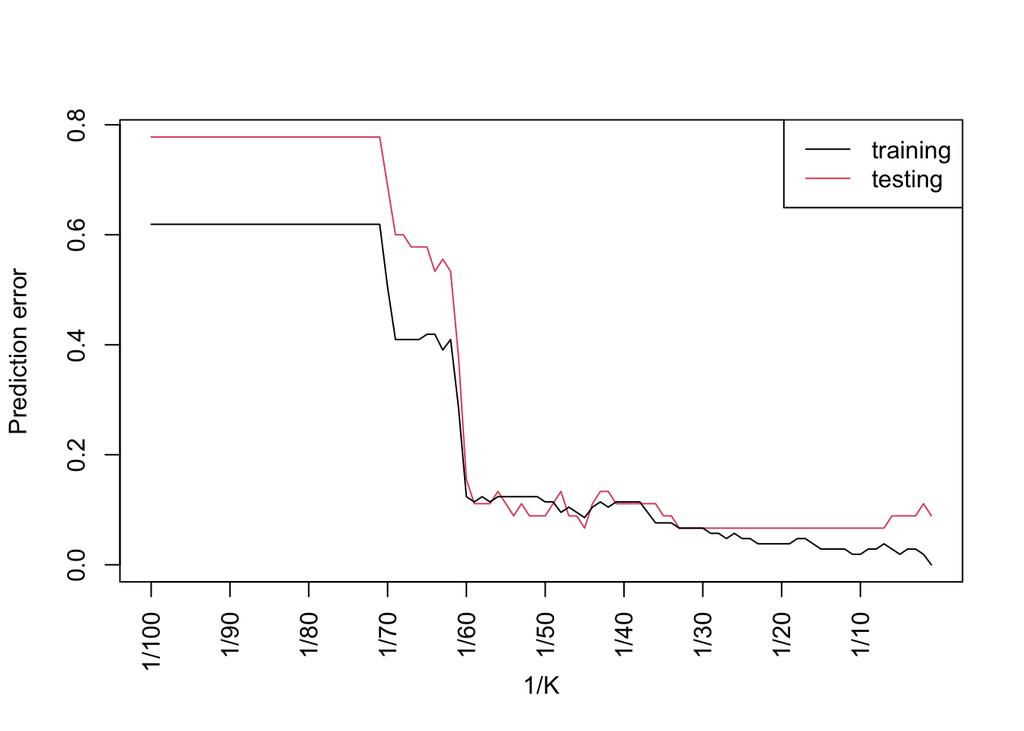

```r
test.error=train.error=rep(NA,100)

for(k in 1:100){
  knn_fit <- knn3(Species ~ Sepal.Length + Petal.Length, data = iris.train, k=k)
  # knn_fit <- knn3(Species ~ ., data = iris.train, k=k)
  y_hat_knn <- predict(knn_fit, iris.train, type = "class")
  train.error[k]=1-confusionMatrix(y_hat_knn, iris.train$Species)$overall["Accuracy"]
  y_hat_knn <- predict(knn_fit, iris.test, type = "class")
  test.error[k]=1-confusionMatrix(y_hat_knn, iris.test$Species)$overall["Accuracy"]
}

plot(1:100, test.error[100:1], type='l', ylim=c(0, max(c(train.error, test.error))), col=2, xaxt="n", ylab='Prediction error', xlab='1/K')
points(1:100, train.error[100:1], type='l')
axis(1, at=seq(1,100,10),labels=paste('1/',seq(100,10,-10),sep=''), las=2)
legend('topright', col=c(1,2), legend=c('training','testing'), lty=c(1,1))
```